# Lab 05 - Data Wrangling

```r
#install.packages(c("data.table","leaflet"))
library(data.table)
library(dtplyr)
library(dplyr)
library(leaflet)
library(tidyverse)
```

```r
library(ggplot2)
library(mgcv)
```

# Learning goals

- Use the `merge()` function to join two datasets.
- Deal with missings and impute data.
- Identify relevant observations using `quantile()`.
- Practice your GitHub skills.

# Lab description

For this lab we will be dealing with the meteorological dataset `met`. In this case, we will use `data.table` to answer some questions regarding the `met` dataset, while at the same time practice your Git+GitHub skills for this project.

This markdown document should be rendered using `github_document` document.

# Part 1: Setup a Git project and the GitHub repository

1. Go to wherever you are planning to store the data on your computer, and create a folder for this project
2. In that folder, save [this template](https://github.com/JSC370/jsc370-2023/blob/main/labs/lab05/lab05-wrangling-gam.Rmd) as “README.Rmd”. This will be the markdown file where all the magic will happen.
3. Go to your GitHub account and create a new repository of the same name that your local folder has, e.g., “JSC370-labs”.
4. Initialize the Git project, add the “README.Rmd” file, and make your first commit.
5. Add the repo you just created on GitHub.com to the list of remotes, and push your commit to origin while setting the upstream.

Most of the steps can be done using command line:

```bash
# Step 1
cd ~/Documents
mkdir JSC370-labs
cd JSC370-labs

# Step 2
wget https://raw.githubusercontent.com/JSC370/jsc370-2023/main/labs/lab05/lab05-wrangling-gam.Rmd
mv lab05-wrangling-gam.Rmd README.Rmd
# if wget is not available,
curl https://raw.githubusercontent.com/JSC370/jsc370-2023/main/labs/lab05/lab05-wrangling-gam.Rmd --output README.Rmd

# Step 3
# Happens on github

# Step 4
git init
git add README.Rmd
git commit -m "First commit"

# Step 5
git remote add origin git@github.com:[username]/JSC370-labs
git push -u origin master
```

You can also complete the steps in R (replace with your paths/username when needed)

```r
# Step 1
setwd("~/Documents")
dir.create("JSC370-labs")
setwd("JSC370-labs")

# Step 2
download.file(
  "https://raw.githubusercontent.com/JSC370/jsc370-2023/main/labs/lab05/lab05-wrangling-gam.Rmd",
  destfile = "README.Rmd"
  )

# Step 3: Happens on Github

# Step 4
system("git init && git add README.Rmd")
system('git commit -m "First commit"')

# Step 5
system("git remote add origin git@github.com:[username]/JSC370-labs")
system("git push -u origin master")
```

Once you are done setting up the project, you can now start working with the MET data.

## Setup in R

1. Load the `data.table` (and the `dtplyr` and `dplyr` packages if you plan to work with those).
2. Load the met data from https://github.com/JSC370/jsc370-2023/blob/main/labs/lab03/met_all.gz or (Use https://raw.githubusercontent.com/JSC370/jsc370-2023/main/labs/lab03/met_all.gz to download programmatically), and also the station data. For the latter, you can use the code we used during lecture to pre-process the stations data:

```r
# Download the data
stations <- fread("ftp://ftp.ncdc.noaa.gov/pub/data/noaa/isd-history.csv")
stations[, USAF := as.integer(USAF)]
# Dealing with NAs and 999999
stations[, USAF   := fifelse(USAF == 999999, NA_integer_, USAF)]
stations[, CTRY   := fifelse(CTRY == "", NA_character_, CTRY)]
stations[, STATE  := fifelse(STATE == "", NA_character_, STATE)]

# Selecting the three relevant columns, and keeping unique records
stations <- unique(stations[, list(USAF, CTRY, STATE)])

# Dropping NAs
stations <- stations[!is.na(USAF)]

# Removing duplicates
stations[, n := 1:.N, by = .(USAF)]
stations <- stations[n == 1,][, n := NULL]
```

3. Merge the data as we did during the lecture.

```r
met <- merge(x = met, y = stations, all.x = TRUE, all.y = FALSE, by.x = "USAFID", by.y= "USAF")
### Tidyverse
# met <- left_join(met, stations, by = c("USAFID" = "USAF"))
met_lz <- lazy_dt(met, immutable = FALSE)
```

## Question 1: Representative station for the US

Across all weather stations, what is the median station in terms of temperature, wind speed, and atmospheric pressure? Look for the three weather stations that best represent continental US using the `quantile()` function. Do these three coincide?

Knit the document, commit your changes, and save it on GitHub. Don’t forget to add `README.md` to the tree, the first time you render it.

```r
# Average for each station
met_avg_lz <- met_lz |>
  group_by(USAFID) |>
  summarise(
    across(
      c(temp, wind.sp, atm.press),
      function(x) mean(x, na.rm = TRUE)
    )
    # temp = mean(temp, na.rm = TRUE),
    # wind.sp = mean(wind.sp, na.rm = TRUE),
    # stm.press = mean(atm.press, na.rm = TRUE)
  )
met_avg_lz
```

```
## Source: local data table [1,595 x 4]
## Call:   `_DT1`[, .(temp = (function (x)
## mean(x, na.rm = TRUE))(temp), wind.sp = (function (x)
## mean(x, na.rm = TRUE))(wind.sp), atm.press = (function (x)
## mean(x, na.rm = TRUE))(atm.press)), keyby = .(USAFID)]
##
##   USAFID  temp wind.sp atm.press
##    <int> <dbl>   <dbl>     <dbl>
## 1 690150  33.2    3.48     1010.
## 2 720110  31.2    2.14      NaN
## 3 720113  23.3    2.47      NaN
## 4 720120  27.0    2.50      NaN
## 5 720137  21.9    1.98      NaN
## 6 720151  27.6    3.00      NaN
## # … with 1,589 more rows
##
## # Use as.data.table()/as.data.frame()/as_tibble() to access results
```

```r
# Median for each station
met_med_lz <- met_avg_lz |>
  summarise(
    across(
      2:4,
      function(x) quantile(x, prob = 0.5, na.rm = TRUE)
    )
  )

met_med_lz
```

```
## Source: local data table [1 x 3]
## Call:   `_DT1`[, .(temp = (function (x)
## mean(x, na.rm = TRUE))(temp), wind.sp = (function (x)
## mean(x, na.rm = TRUE))(wind.sp), atm.press = (function (x)
## mean(x, na.rm = TRUE))(atm.press)), keyby = .(USAFID)][, .(temp = (function (x)
## quantile(x, prob = 0.5, na.rm = TRUE))(temp), wind.sp = (function (x)
## quantile(x, prob = 0.5, na.rm = TRUE))(wind.sp), atm.press = (function (x)
## quantile(x, prob = 0.5, na.rm = TRUE))(atm.press))]
##
##    temp wind.sp atm.press
##   <dbl>   <dbl>     <dbl>
## 1  23.7    2.46     1015.
##
## # Use as.data.table()/as.data.frame()/as_tibble() to access results
```

```r
# Temperature
temp_us_id <- met_avg_lz |>
  mutate(
    temp_diff = abs(temp - met_med_lz |> pull(temp))
    ) |>
  arrange(temp_diff) |>
  slice(1) |>
  pull (USAFID)

# Wind Speed
wind_us_id <- met_avg_lz |>
  mutate(
    wind_diff = abs(wind.sp - met_med_lz |> pull(wind.sp))
    ) |>
  arrange(wind_diff) |>
  slice(1) |>
  pull (USAFID)

# atm Speed
atm_us_id <- met_avg_lz |>
  mutate(
    d = abs(atm.press - met_med_lz |> pull(atm.press))
    ) |>
  arrange(d) %>%
  slice(1) %>%
  pull (USAFID)

cat("ID with median ...",
    "\n    temperature: ", temp_us_id,
    "\n    wind: ", wind_us_id,
    "\n    atm: ", atm_us_id)
```

```
## ID with median ...
##     temperature:  720458
##     wind:  720929
##     atm:  722238
```

```r
met_lz |>
  select(USAFID, lon, lat) %>%
  distinct() %>%
  filter(USAFID %in% c(temp_us_id, wind_us_id, atm_us_id))
```

```
## Source: local data table [4 x 3]
## Call:   unique(`_DT1`[, .(USAFID, lon, lat)])[USAFID %in% c(temp_us_id,
##     wind_us_id, atm_us_id)]
##
##   USAFID   lon   lat
##    <int> <dbl> <dbl>
## 1 720458 -82.6  37.8
## 2 720929 -92.0  45.5
## 3 722238 -85.7  31.4
## 4 722238 -85.7  31.3
##
## # Use as.data.table()/as.data.frame()/as_tibble() to access results
```

These three stations does not coincide as we have three different station. The station that represent temperature is 720458, the wind is 720929, the atmospheric pressure is 722238.

## Question 2: Representative station per state

Just like the previous question, you are asked to identify what is the most representative, the median, station per state. This time, instead of looking at one variable at a time, look at the euclidean distance. If multiple stations show in the median, select the one located at the lowest latitude.

```r
# mean for each station
met_avg_state_lz <- met |>
  group_by(USAFID) |>
  summarise(
    temp = mean(temp, na.rm = TRUE),
    wind.sp = mean(wind.sp, na.rm = TRUE),
    atm.press = mean(atm.press, na.rm = TRUE),
    STATE = unique(STATE), lat = unique(lat, na.rm = TRUE)[1], lon = unique(lon, na.rm = TRUE)[1]
  )
met_avg_state_lz <- na.omit(met_avg_state_lz)
met_avg_state_lz
```

```
## Source: local data table [1,595 x 7]
## Call:   `_DT2`[, .(temp = mean(temp, na.rm = TRUE), wind.sp = mean(wind.sp,
##     na.rm = TRUE), atm.press = mean(atm.press, na.rm = TRUE),
##     STATE = unique(STATE), lat = unique(lat, na.rm = TRUE)[1],
##     lon = unique(lon, na.rm = TRUE)[1]), keyby = .(USAFID)]
##
##   USAFID  temp wind.sp atm.press STATE   lat    lon
##    <int> <dbl>   <dbl>     <dbl> <chr> <dbl>  <dbl>
## 1 690150  33.2    3.48     1010. CA     34.3 -116.
## 2 720110  31.2    2.14      NaN  TX     30.8  -98.7
## 3 720113  23.3    2.47      NaN  MI     42.5  -83.2
## 4 720120  27.0    2.50      NaN  SC     32.2  -80.7
## 5 720137  21.9    1.98      NaN  IL     41.4  -88.4
## 6 720151  27.6    3.00      NaN  TX     30.4 -104.
## # … with 1,589 more rows
##
## # Use as.data.table()/as.data.frame()/as_tibble() to access results
```

```r
# Median of all state
met_med_avg_state_lz <- met_avg_state_lz %>%
  group_by(STATE) %>%
  summarise(across(
    c(temp, wind.sp, atm.press),
    function(x) quantile(x, 0.5, na.rm = TRUE)
  ))
```

```r
met_means_med_state <- merge(
  x = met_avg_state_lz,
  y = met_med_avg_state_lz,
  by.x = "STATE",
  by.y = "STATE",
  all.x = TRUE,
  all.y = TRUE,
  na.rm = TRUE
 )
```

```r
udist <- function(pt1, pt2, pt3, pt4, pt5, pt6) {
  sqrt((pt1 - pt2)^2 + (pt3 - pt4)^2 + (pt5 - pt6)^2)
}
```

```r
met_means_med_state$euclid <-udist(met_means_med_state$temp.x, met_means_med_state$wind.sp.y, met_means_med_state$wind.sp.x, met_means_med_state$atm.press.x, met_means_med_state$temp.y, met_means_med_state$atm.press.y)

met_means_med_state_answer <- met_means_med_state |>
  group_by(STATE) |>
  slice_min(euclid) |> slice_min(lat)
met_means_med_state_answer
```

```
## # A tibble: 48 × 11
## # Groups:   STATE [48]
##    STATE USAFID temp.x wind.sp.x atm.press.x   lat    lon temp.y wind.…¹ atm.p…²
##    <chr>  <int>  <dbl>     <dbl>       <dbl> <dbl>  <dbl>  <dbl>   <dbl>   <dbl>
##  1 AL    722239   25.8      1.19       1013.  31.4  -85.8   26.3    1.66   1015.
##  2 AR    723440   27.2      2.60       1014.  35.3  -94.4   26.2    1.94   1015.
##  3 AZ    723700   30.3      4.70       1008.  35.3 -114.    30.3    3.07   1010.
##  4 CA    723805   37.6      3.53       1005.  34.8 -115.    22.7    2.57   1013.
##  5 CO    724636   25.0      4.57       1011.  38.1 -103.    21.5    3.10   1013.
##  6 CT    725040   23.4      3.15       1015.  41.2  -73.1   22.4    2.10   1015.
##  7 DE    724088   24.7      3.03       1015.  39.1  -75.5   24.6    2.75   1015.
##  8 FL    722104   28.3      3.63       1015.  27.8  -82.6   27.6    2.71   1015.
##  9 GA    722137   27.9      3.43       1015.  31.2  -81.4   26.7    1.50   1015.
## 10 IA    725460   22.6      3.26       1015.  41.5  -93.7   21.3    2.68   1015.
## # … with 38 more rows, 1 more variable: euclid <dbl>, and abbreviated variable
## #   names ¹wind.sp.y, ²atm.press.y
```

```r
nrow(met_means_med_state_answer)
```

```
## [1] 48
```

```r
length(unique(met$STATE))
```

```
## [1] 48
```

Knit the doc and save it on GitHub.

We have checked that the result has the same number of unique states from the data.

## Question 3: In the middle?

For each state, identify what is the station that is closest to the mid-point of the state. Combining these with the stations you identified in the previous question, use `leaflet()` to visualize all ~100 points in the same figure, applying different colors for those identified in this question.

```r
met_lon_lat_avg <- met_lz %>% group_by(STATE) %>%
  summarise(lon = mean(lon, na.rm = TRUE),
            lat = mean(lat, na.rm = TRUE))
data.frame(met_lon_lat_avg)
```

```
##    STATE        lon      lat
## 1     AL  -86.65318 32.75554
## 2     AR  -92.68849 35.18904
## 3     AZ -111.54154 33.91659
## 4     CA -120.03186 36.50457
## 5     CO -105.69753 39.12441
## 6     CT  -72.71733 41.48119
## 7     DE  -75.47708 39.15950
## 8     FL  -82.39921 28.33518
## 9     GA  -83.33168 32.56718
## 10    IA  -93.49382 41.85552
## 11    ID -115.17229 45.02638
## 12    IL  -88.81862 40.22512
## 13    IN  -86.33665 40.51988
## 14    KS  -97.96264 38.32236
```

[output cut: 34 more lines]

```r
met_lon_lat_avg$category <- 'median'
```

```r
met_means_med_state_answer_filter <- met_means_med_state_answer %>% select(STATE, lat, lon)
met_means_med_state_answer_filter$category <- 'median'
lat_lon_answer <- rbind(met_means_med_state_answer_filter, data.frame(met_lon_lat_avg))
lat_lon_answer
```

```
## # A tibble: 96 × 4
## # Groups:   STATE [48]
##    STATE   lat    lon category
##    <chr> <dbl>  <dbl> <chr>
##  1 AL     31.4  -85.8 median
##  2 AR     35.3  -94.4 median
##  3 AZ     35.3 -114.  median
##  4 CA     34.8 -115.  median
##  5 CO     38.1 -103.  median
##  6 CT     41.2  -73.1 median
##  7 DE     39.1  -75.5 median
##  8 FL     27.8  -82.6 median
##  9 GA     31.2  -81.4 median
## 10 IA     41.5  -93.7 median
## # … with 86 more rows
```

```r
pal <- colorFactor(c("navy", "red"), domain = c("mean", "median"))
leaflet(lat_lon_answer) |>
  addProviderTiles('OpenStreetMap') |>
  addCircleMarkers(lat = ~lat, lng = ~lon, opacity = 0.7, radius = 5, color = ~pal(category))
```

[interactive chart not shown]

Knit the doc and save it on GitHub.

## Question 4: Means of means

Using the `quantile()` function, generate a summary table that shows the number of states included, average temperature, wind-speed, and atmospheric pressure by the variable “average temperature level,” which you’ll need to create.

Start by computing the states’ average temperature. Use that measurement to classify them according to the following criteria:

- low: temp < 20
- Mid: temp >= 20 and temp < 25
- High: temp >= 25

```r
met_avg_state_lz_q4 <- met |>
  group_by(STATE) |>
  summarise(
    number_of_na = sum(is.na(temp)),
    temp = mean(temp, na.rm = TRUE),
    wind.sp = mean(wind.sp, na.rm = TRUE),
    atm.press = mean(atm.press, na.rm = TRUE),
    STATE = unique(STATE), number_of_station = n()
  )
unique(data.frame(met_avg_state_lz_q4))
```

```
##    number_of_na     temp  wind.sp atm.press STATE number_of_station
## 1          1400 26.19799 1.566381  1016.148    AL             44743
## 2          1968 26.20697 1.836963  1014.551    AR             34829
## 3           937 28.80596 2.984547  1010.771    AZ             34150
## 4          5040 22.36199 2.614120  1012.640    CA            109392
## 5          1645 19.54725 3.075255  1013.725    CO             78843
## 6           305 22.25797 2.194895  1015.036    CT             11767
## 7           132 24.58116 2.762484  1015.058    DE              3231
## 8          3632 27.53747 2.501976  1015.242    FL             80933
## 9          3615 26.53857 1.509138  1015.168    GA             89241
## 10         2903 21.27773 2.568719  1015.210    IA            107995
## 11          362 20.69554 2.380664  1013.222    ID             16005
## 12         1078 22.41005 2.171944  1014.215    IL             73792
## 13         1566 21.76562 2.260783  1015.035    IN             38489
## 14         1034 24.25538 3.729569  1013.360    KS             40707
```

[output cut: 34 more lines]

```r
met_avg_state_lz_q4 <- met_avg_state_lz_q4 %>% mutate("average temperature level" =
  case_when(temp >= 25 ~ "High",
            temp < 20 ~ "Low",
            temp >=20 & temp < 25 ~ "Mid")
)
met_avg_state_lz_q4
```

```
## Source: local data table [48 x 7]
## Call:   `_DT3`[, .(number_of_na = sum(is.na(temp)), temp = mean(temp,
##     na.rm = TRUE), wind.sp = mean(wind.sp, na.rm = TRUE), atm.press = mean(atm.press,
##     na.rm = TRUE), STATE = unique(STATE), number_of_station = .N),
##     keyby = .(STATE)][, `:=`("STATE", NULL)][, `:=`(`average temperature level` = fcase(temp >=
##     25, "High", temp < 20, "Low", temp >= 20 & temp < 25, "Mid"))]
##
##   number_of_na  temp wind.sp atm.press STATE number_of_station average tempera…¹
##          <int> <dbl>   <dbl>     <dbl> <chr>             <int> <chr>
## 1         1400  26.2    1.57     1016. AL                44743 High
## 2         1968  26.2    1.84     1015. AR                34829 High
## 3          937  28.8    2.98     1011. AZ                34150 High
## 4         5040  22.4    2.61     1013. CA               109392 Mid
## 5         1645  19.5    3.08     1014. CO                78843 Low
## 6          305  22.3    2.19     1015. CT                11767 Mid
## # … with 42 more rows, and abbreviated variable name
## #   ¹`average temperature level`
##
## # Use as.data.table()/as.data.frame()/as_tibble() to access results
```

Once you are done with that, you can compute the following:

- Number of entries (records),
- Number of NA entries,
- Number of stations,
- Number of states included, and
- Mean temperature, wind-speed, and atmospheric pressure.

All by the levels described before.

```r
met_avg_state_lz_q4_answer <- met_avg_state_lz_q4 %>%
  group_by(c(`average temperature level`)) %>%
  summarise(
    num_entries = n(),
    num_NA = sum(number_of_na),
    num_stations = sum(number_of_station),
    num_states = length(STATE),
    mean_temp = mean(temp, na.rm = TRUE),
    mean_wind.sp = mean(wind.sp, na.rm = TRUE),
    mean_atm.press = mean(atm.press, na.rm = TRUE)
  )
met_avg_state_lz_q4_answer
```

```
## Source: local data table [3 x 8]
## Call:   `_DT3`[, .(number_of_na = sum(is.na(temp)), temp = mean(temp,
##     na.rm = TRUE), wind.sp = mean(wind.sp, na.rm = TRUE), atm.press = mean(atm.press,
##     na.rm = TRUE), STATE = unique(STATE), number_of_station = .N),
##     keyby = .(STATE)][, `:=`("STATE", NULL)][, `:=`(`average temperature level` = fcase(temp >=
##     25, "High", temp < 20, "Low", temp >= 20 & temp < 25, "Mid"))][,
##     `:=`(`c(\`average temperature level\`)` = c(`average temperature level`))][,
##     .(num_entries = .N, num_NA = sum(number_of_na), num_stations = sum(number_of_station),
##         num_states = length(STATE), mean_temp = mean(temp, na.rm = TRUE),
##         mean_wind.sp = mean(wind.sp, na.rm = TRUE), mean_atm.press = mean(atm.press,
##             na.rm = TRUE)), keyby = .(`c(\`average temperature level\`)`)]
##
##   c(\average temperatur…¹ num_e…² num_NA num_s…³ num_s…⁴ mean_…⁵ mean_…⁶ mean_…⁷
##   <chr>                     <int>  <int>   <int>   <int>   <dbl>   <dbl>   <dbl>
## 1 High                         12  23468  811126      12    27.0    2.43   1014.
## 2 Low                          11   7369  430794      11    18.7    2.55   1014.
## 3 Mid                          25  29252 1135423      25    22.6    2.39   1015.
## # … with abbreviated variable names ¹`c(\`average temperature level\`)`,
## #   ²num_entries, ³num_stations, ⁴num_states, ⁵mean_temp, ⁶mean_wind.sp,
## #   ⁷mean_atm.press
##
## # Use as.data.table()/as.data.frame()/as_tibble() to access results
```

Knit the document, commit your changes, and push them to GitHub.

## Question 5: Advanced Regression

Let’s practice running regression models with smooth functions on X. We need the `mgcv` package and `gam()` function to do this.

- using your data with the median values per station, examine the association between median temperature (y) and median wind speed (x). Create a scatterplot of the two variables using ggplot2. Add both a linear regression line and a smooth line.

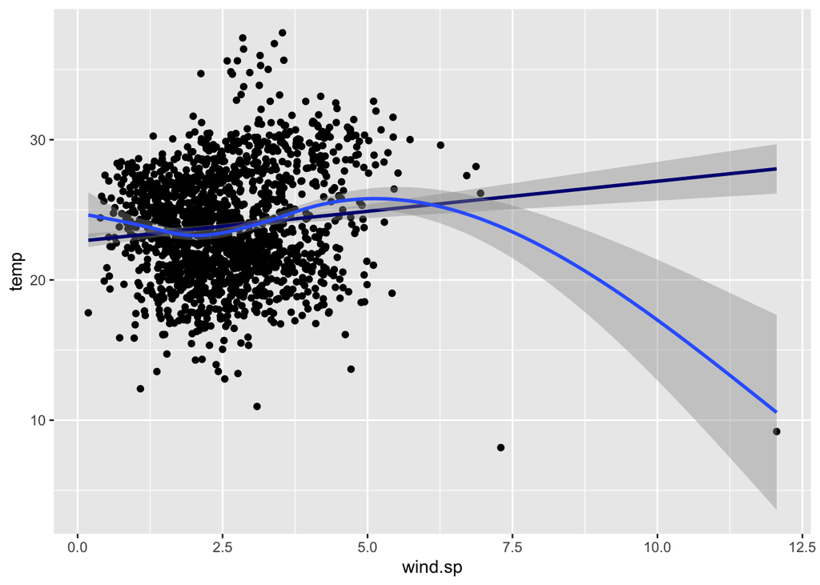

```r
met_med_lz_q5 <- met_lz |>
  group_by(USAFID) |>
  summarise(
    temp = mean(temp, na.rm = TRUE),
    wind.sp = mean(wind.sp, na.rm = TRUE)
  )

met_med_lz_q5 %>% as.data.frame() %>%
  filter(!is.na(wind.sp) & !is.na(temp)) %>%
  ggplot(aes(x = wind.sp, y = temp)) +
  geom_point() + geom_smooth(method = "lm", formula = y~x, color = "navy") + geom_smooth()
```

- fit both a linear model and a spline model (use `gam()` with a cubic regression spline on wind speed). Summarize and plot the results from the models and interpret which model is the best fit and why.

```r
model1 <- lm(temp ~ wind.sp, data = met_med_lz_q5)
summary(model1)
```

```
##
## Call:
## lm(formula = temp ~ wind.sp, data = met_med_lz_q5)
##
## Residuals:
##      Min       1Q   Median       3Q      Max
## -18.7305  -2.9533  -0.0788   3.0842  13.3611
##
## Coefficients:
##             Estimate Std. Error t value Pr(>|t|)
## (Intercept) 22.74895    0.26281  86.562  < 2e-16 ***
## wind.sp      0.42892    0.09423   4.552 5.72e-06 ***
## ---
## Signif. codes:  0 '***' 0.001 '**' 0.01 '*' 0.05 '.' 0.1 ' ' 1
##
## Residual standard error: 3.98 on 1577 degrees of freedom
##   (16 observations deleted due to missingness)
## Multiple R-squared:  0.01297,    Adjusted R-squared:  0.01234
## F-statistic: 20.72 on 1 and 1577 DF,  p-value: 5.722e-06
```

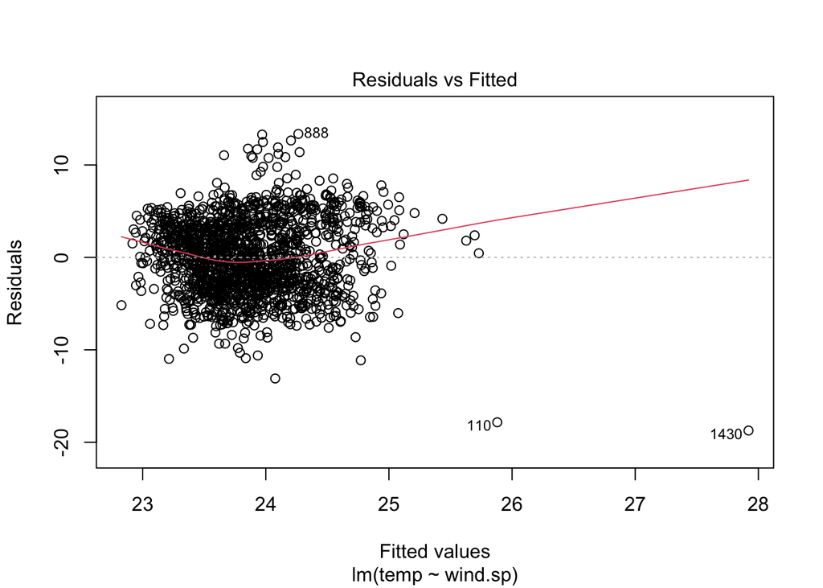

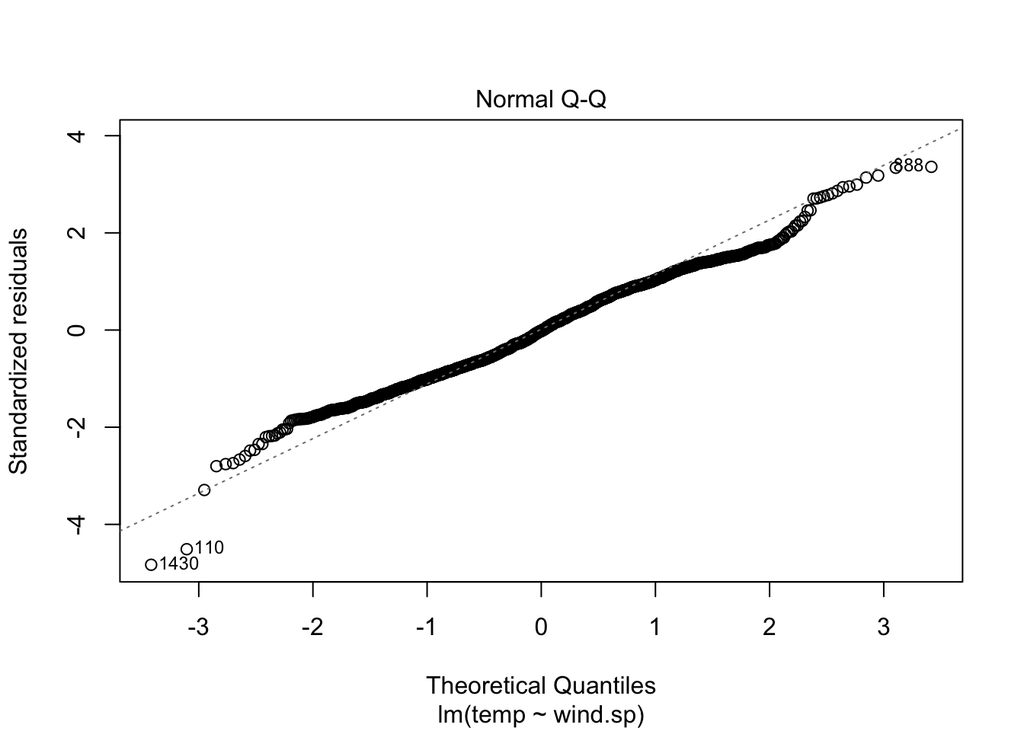

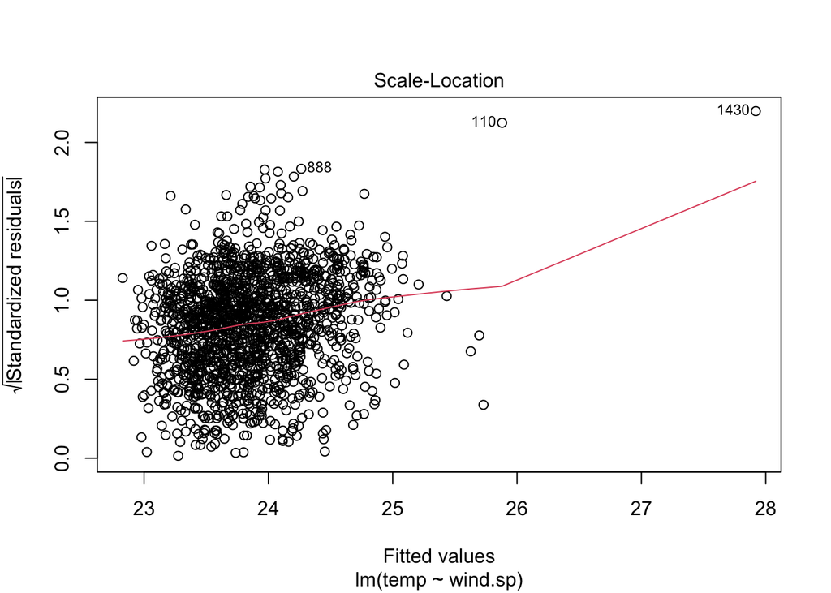

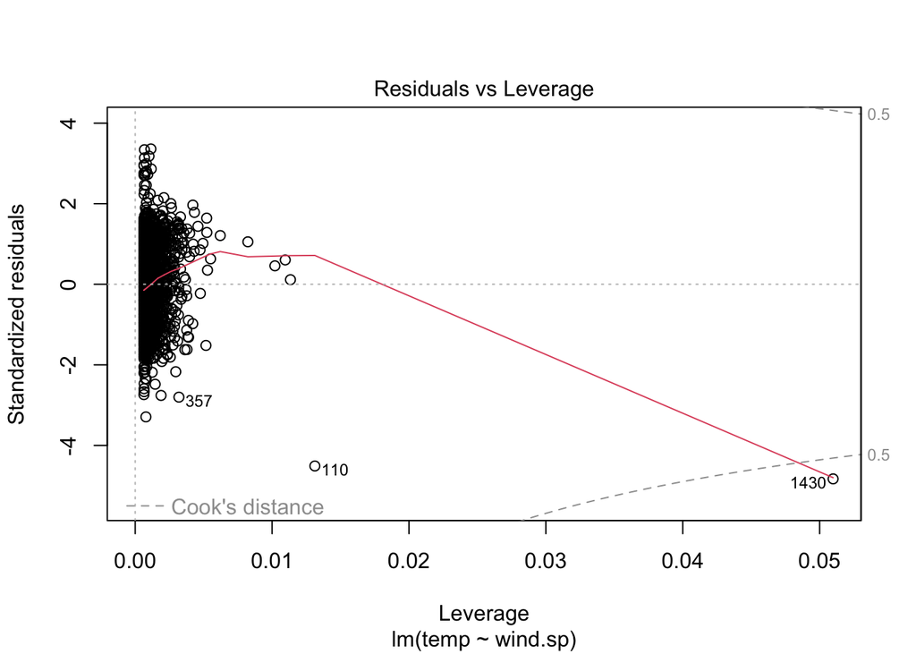

```r
plot(model1)
```

```r
model2 <- gam(temp~s(wind.sp, bs = "cr", k=20), data = data.frame(met_med_lz_q5))
```

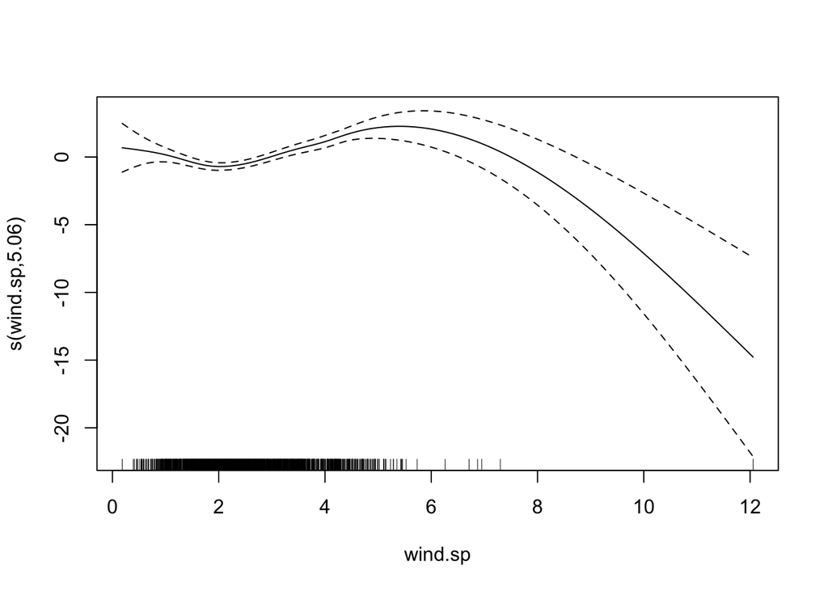

```r
plot(model2)
```

```r
summary(model2)
```

```
##
## Family: gaussian
## Link function: identity
##
## Formula:
## temp ~ s(wind.sp, bs = "cr", k = 20)
##
## Parametric coefficients:
##             Estimate Std. Error t value Pr(>|t|)
## (Intercept)  23.8550     0.0985   242.2   <2e-16 ***
## ---
## Signif. codes:  0 '***' 0.001 '**' 0.01 '*' 0.05 '.' 0.1 ' ' 1
##
## Approximate significance of smooth terms:
##             edf Ref.df     F p-value
## s(wind.sp) 5.06  6.116 12.13  <2e-16 ***
## ---
## Signif. codes:  0 '***' 0.001 '**' 0.01 '*' 0.05 '.' 0.1 ' ' 1
##
## R-sq.(adj) =  0.0446   Deviance explained = 4.77%
## GCV =  15.38  Scale est. = 15.321    n = 1579
```

The linear model has a p-value lower than 0.05 and also for the spline model. Notice that the spline model has an extremely small p-value which could possibly (but not sure) that be better than the linear model. I think the spline model will be better as the R-squared adjusted is higher.